# **Title: Practical Machine Learning Course Project using Weight Lifting Exercises Dataset from Human Activity Recognition (HAR) Research**

- Author: Rama Neti
- Date: March 20, 2016

# **Executive Summary**

### The goal of the project is to use data from accelerometers on the belt, forearm, arm, and dumbbell of six male participants aged between 20-28 years, with little weight lifting experience for predicting the manner in which they did the exercise. The exercise involves performing barbell lifts correctly and incorrectly in 5 different ways (Class A: exactly according to the specification; Class B: throwing the elbows to the front; Class C: lifting the dumbbell only halfway; Class D: lowering the dumbbell only halfway; Class E: throwing the hips to the front)

### The main objectives of this project are as follows

### (i) Predict the manner in which the participants did the exercise using the “classe” and any other variables

### (ii) Build a prediction model using different features and cross-validation technique

### (iii) Calculate the out of sample error

### (iv) Use the prediction model to predict 20 different test cases provided

### (v) This classifier predicts if an exercise has been done correctly (class A)

### More information on the dataset can be found on the website: http://groupware.les.inf.puc-rio.br/har

## **1. Data**

### The training data for this project are available here: https://d396qusza40orc.cloudfront.net/predmachlearn/pml-training.csv

### The test data are available here: https://d396qusza40orc.cloudfront.net/predmachlearn/pml-testing.csv

## **2. Download and Read Training and Testing Data into Data Frames**

```r
# Set Working Directory
  setwd("D:/Documents/DataScience/Machine Learning/Project")

# Load Libraries
  library(caret)
  library(randomForest)
  library(rpart)
  library(rpart.plot)
  library(ggplot2)
  library(lattice)
  library(rattle)
  library(ipred)
  options(warn=-1)

  trainURL <- "https://d396qusza40orc.cloudfront.net/predmachlearn/pml-training.csv"
  testURL <- "https://d396qusza40orc.cloudfront.net/predmachlearn/pml-testing.csv"
  trainFile <- "D:/Documents/DataScience/Machine Learning/Project/training.csv"
  testFile  <- "D:/Documents/DataScience/Machine Learning/Project/testing.csv"

  if (!file.exists(trainFile)) {
  download.file(trainURL, destfile=trainFile)
  }

  if (!file.exists(testFile)) {
  download.file(testURL, destfile=testFile)
  }
# (a) Load training and testing data (b) Replace invalid strings as "NA"
  trainingDataSet <- read.csv("./training.csv" ,na.strings=c("NA","#DIV/0!",""))
  testingDataSet <- read.csv("./testing.csv" ,na.strings=c("NA","#DIV/0!",""))
  dim(trainingDataSet)
```

```
## [1] 19622   160
```

```r
  dim(testingDataSet)
```

```
## [1]  20 160
```

## **3. Data Cleansing and Preproccesing of the variables**

```r
# Remove unnecessary columns
# Drop first 7 columns that do not contain useful info such as X, user_name, raw_timestamp_part_1, raw_timestamp_part_2, cvtd_timestamp, new_window, num_window that are irrelevant

  training  <- trainingDataSet[,-c(1:7)]
  testing <- testingDataSet[,-c(1:7)]

  dim(training)
```

```
## [1] 19622   153
```

```r
  dim(testing)
```

```
## [1]  20 153
```

```r
# Remove columns with NAs This reduces the number of predictors to 53

  training <- training [,colSums(is.na(training))==0]
  testing <- testing [,colSums(is.na(testing))==0]

  dim(training)
```

```
## [1] 19622    53
```

```r
  dim(testing)
```

```
## [1] 20 53
```

```r
# Remove highly correlated variables Highly correlated variables can sometimes reduce the performance of a model, and will be excluded. However, this way of selection is disputable: http://arxiv.org/abs/1310.5726

# Set last (classe) and prior (- classe) column index
  last <- as.numeric(ncol(training))
  prior <- last - 1

# set variables to numerics for correlation check, except the "classe"
  for (i in 1:prior) {
  training[,i] <- as.numeric(training [,i])
  testing [,i] <- as.numeric(testing [,i])
  }

# Find the highly correlated variables
  highly.cor <- findCorrelation(cor(training [, -c(last)]), cutoff=0.9)

# Remove highly correlated variables
  training <- training [, -highly.cor]
  testing <- testing [, -highly.cor]

  dim(training)
```

```
## [1] 19622    46
```

```r
  dim(testing)
```

```
## [1] 20 46
```

```r
# Pre-proccesing of the variables. The amount of predictors is now 46. We will continue with the pre-processing of these predictors, by centering and scaling them. Remember that the last column of the validation set contained the problem_id.

# Pre-process variables
  prior <- ncol(training) - 1
  preObj <-preProcess(training[,1:prior],method=c('knnImpute', 'center', 'scale'))

  TrainDataPrep <- predict(preObj, training[,1:prior])
  TrainDataPrep$classe <- training$classe

  TestDataPrep <-predict(preObj,testing[,1:prior])
  TestDataPrep$problem_id <- testing$problem_id
```

## **4. Create a cross validation data set**

### We now perform cross validation by splitting the training data into training (75%) and validation (25%) and fitting a model using training data and then predicting it using validation data. The accuracy of prediction should reflect the accuracy of the model.

```r
# Divide training data to training and validation (75% training, 25% validation)
  inTrain <- createDataPartition(y= TrainDataPrep$classe, p=0.75, list=F)
  training <- TrainDataPrep[inTrain,]
  validation <- TrainDataPrep[-inTrain,]
  dim(training)
```

```
## [1] 14718    46
```

```r
  dim(validation)
```

```
## [1] 4904   46
```

```r
  summary(training)
```

```
##    pitch_belt           yaw_belt          total_accel_belt
##  Min.   :-2.510164   Min.   :-1.7731692   Min.   :-1.4611414
##  1st Qu.: 0.065532   1st Qu.:-0.8098725   1st Qu.:-1.0736601
##  Median : 0.223018   Median :-0.0199061   Median : 0.7345860
##  Mean   :-0.001798   Mean   : 0.0005556   Mean   :-0.0009651
##  3rd Qu.: 0.652971   3rd Qu.: 0.2605740   3rd Qu.: 0.8637464
##  Max.   : 2.684178   Max.   : 1.9980798   Max.   : 2.1553508
##   gyros_belt_x       gyros_belt_y        gyros_belt_z
##  Min.   :-4.79628   Min.   :-8.686434   Min.   :-5.053275
##  1st Qu.:-0.11772   1st Qu.:-0.506007   1st Qu.:-0.287842
##  Median : 0.17167   Median :-0.250368   Median : 0.126544
##  Mean   : 0.01015   Mean   : 0.001101   Mean   :-0.002657
##  3rd Qu.: 0.55753   3rd Qu.: 0.900004   3rd Qu.: 0.458052
##  Max.   :10.73459   Max.   : 7.674420   Max.   : 7.253974
##  magnet_belt_x       magnet_belt_y       magnet_belt_z
##  Min.   :-1.676567   Min.   :-6.577112   Min.   :-4.255806
##  1st Qu.:-0.726104   1st Qu.:-0.355288   1st Qu.:-0.437346
##  Median :-0.320989   Median : 0.205236   Median : 0.406088
##  Mean   : 0.000387   Mean   : 0.000979   Mean   : 0.004092
##  3rd Qu.: 0.052963   3rd Qu.: 0.457472   3rd Qu.: 0.605446
##  Max.   : 6.690619   Max.   : 2.223125   Max.   : 9.791217
##     roll_arm           pitch_arm             yaw_arm
##  Min.   :-2.719537   Min.   :-2.7438956   Min.   :-2.513631
##  1st Qu.:-0.686038   1st Qu.:-0.6905713   1st Qu.:-0.598083
##  Median :-0.245109   Median : 0.1503139   Median : 0.008670
##  Mean   :-0.001714   Mean   :-0.0002476   Mean   :-0.001124
##  3rd Qu.: 0.818896   3rd Qu.: 0.5186086   3rd Qu.: 0.650456
##  Max.   : 2.229321   Max.   : 3.0347458   Max.   : 2.530972
##  total_accel_arm      gyros_arm_y         gyros_arm_z
##  Min.   :-2.329208   Min.   :-3.738495   Min.   :-4.699253
##  1st Qu.:-0.808624   1st Qu.:-0.625940   1st Qu.:-0.613701
##  Median : 0.141741   Median : 0.020062   Median :-0.035216
##  Mean   : 0.007555   Mean   : 0.000708   Mean   : 0.008319
##  3rd Qu.: 0.711960   3rd Qu.: 0.466391   3rd Qu.: 0.814435
##  Max.   : 3.848165   Max.   : 3.637673   Max.   : 4.972297
##   accel_arm_x         accel_arm_y         accel_arm_z
##  Min.   :-1.772968   Min.   :-3.191133   Min.   :-4.194155
##  1st Qu.:-0.998434   1st Qu.:-0.797308   1st Qu.:-0.547741
##  Median : 0.083717   Median :-0.178373   Median : 0.180056
##  Mean   :-0.004637   Mean   :-0.004719   Mean   :-0.007664
```

[output cut: 50 more lines]

```
##  Max.   :  5.87719   Max.   :100.27489   Max.   :131.57654
##  accel_forearm_x     accel_forearm_y    accel_forearm_z
##  Min.   :-2.416187   Min.   :-3.97569   Min.   :-2.823098
##  1st Qu.:-0.644254   1st Qu.:-0.54792   1st Qu.:-0.908315
##  Median : 0.025759   Median : 0.18160   Median : 0.124944
##  Mean   :-0.003047   Mean   :-0.00337   Mean   : 0.003041
##  3rd Qu.: 0.762218   3rd Qu.: 0.73624   3rd Qu.: 0.587382
##  Max.   : 2.982673   Max.   : 3.79425   Max.   : 2.473262
##  magnet_forearm_x    magnet_forearm_y   magnet_forearm_z   classe
##  Min.   :-2.788299   Min.   :-2.49349   Min.   :-3.70086   A:4185
##  1st Qu.:-0.877408   1st Qu.:-0.74035   1st Qu.:-0.56697   B:2848
##  Median :-0.188565   Median : 0.41204   Median : 0.31653   C:2567
##  Mean   : 0.001442   Mean   :-0.00221   Mean   :-0.00361   D:2412
##  3rd Qu.: 0.693385   3rd Qu.: 0.69867   3rd Qu.: 0.69972   E:2706
##  Max.   : 2.837734   Max.   : 2.15929   Max.   : 1.85877
```

## **5.Comparison of Classification and Predictive Models**

### We choose Decision Tree, Bagging and Random Forest as we would expect them to give the best results.

### **I. Decision Tree algorithm**

```r
# Set seed for reproducibility
  set.seed(12345)

  modelfitDT <- rpart(classe ~., data=training, method="class")
  prp(modelfitDT)
```

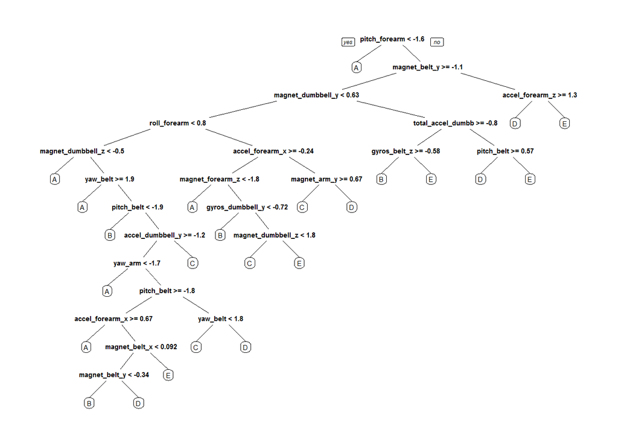

```r
  predictionDT  <- predict(modelfitDT, validation, type="class")

# Summarize Decision Tree results
  resultDT <- confusionMatrix(predictionDT,validation$classe)
  resultDT
```

```
## Confusion Matrix and Statistics
##
##           Reference
## Prediction    A    B    C    D    E
##          A 1262  202   34   77   75
##          B   58  517  104   44  163
##          C   33  114  622   81  141
##          D   39  101   91  595   47
##          E    3   15    4    7  475
##
## Overall Statistics
##
##                Accuracy : 0.7078
##                  95% CI : (0.6948, 0.7205)
##     No Information Rate : 0.2845
##     P-Value [Acc > NIR] : < 2.2e-16
##
##                   Kappa : 0.6282
##  Mcnemar's Test P-Value : < 2.2e-16
##
## Statistics by Class:
##
##                      Class: A Class: B Class: C Class: D Class: E
## Sensitivity            0.9047   0.5448   0.7275   0.7400  0.52719
## Specificity            0.8894   0.9067   0.9089   0.9322  0.99276
## Pos Pred Value         0.7648   0.5835   0.6276   0.6816  0.94246
## Neg Pred Value         0.9591   0.8925   0.9405   0.9482  0.90318
## Prevalence             0.2845   0.1935   0.1743   0.1639  0.18373
## Detection Rate         0.2573   0.1054   0.1268   0.1213  0.09686
## Detection Prevalence   0.3365   0.1807   0.2021   0.1780  0.10277
## Balanced Accuracy      0.8970   0.7257   0.8182   0.8361  0.75997
```

### **II. Bagging Algorithm**

```r
# Use Bootstraping Aggregating method
  modelfitBG <- bagging(classe ~., data=training)
  predictionBG <- predict(modelfitBG, validation)
# Summarize Bagging results
  resultBG <- confusionMatrix(predictionBG, validation$classe)
  resultBG
```

```
## Confusion Matrix and Statistics
##
##           Reference
## Prediction    A    B    C    D    E
##          A 1385    9    0    3    2
##          B    6  926   13    4    4
##          C    3    9  836   10    6
##          D    1    3    5  785    3
##          E    0    2    1    2  886
##
## Overall Statistics
##
##                Accuracy : 0.9825
##                  95% CI : (0.9784, 0.9859)
##     No Information Rate : 0.2845
##     P-Value [Acc > NIR] : <2e-16
##
##                   Kappa : 0.9778
##  Mcnemar's Test P-Value : 0.1933
##
## Statistics by Class:
##
##                      Class: A Class: B Class: C Class: D Class: E
## Sensitivity            0.9928   0.9758   0.9778   0.9764   0.9834
## Specificity            0.9960   0.9932   0.9931   0.9971   0.9988
## Pos Pred Value         0.9900   0.9717   0.9676   0.9849   0.9944
## Neg Pred Value         0.9971   0.9942   0.9953   0.9954   0.9963
## Prevalence             0.2845   0.1935   0.1743   0.1639   0.1837
## Detection Rate         0.2824   0.1888   0.1705   0.1601   0.1807
## Detection Prevalence   0.2853   0.1943   0.1762   0.1625   0.1817
## Balanced Accuracy      0.9944   0.9845   0.9854   0.9867   0.9911
```

### **III. Random Forest (improved bagging) Algorithm**

```r
# Use randomForest model to train and predict
  modelfitRF <- randomForest(classe ~., data=training, na.action=na.omit)
  predictionRF <- predict(modelfitRF, validation, type="class")
# Summarize randomForest results
  resultRF <- confusionMatrix(predictionRF, validation$classe)
  resultRF
```

```
## Confusion Matrix and Statistics
##
##           Reference
## Prediction    A    B    C    D    E
##          A 1395    8    0    0    0
##          B    0  941    4    0    0
##          C    0    0  851    4    0
##          D    0    0    0  800    3
##          E    0    0    0    0  898
##
## Overall Statistics
##
##                Accuracy : 0.9961
##                  95% CI : (0.994, 0.9977)
##     No Information Rate : 0.2845
##     P-Value [Acc > NIR] : < 2.2e-16
##
##                   Kappa : 0.9951
##  Mcnemar's Test P-Value : NA
##
## Statistics by Class:
##
##                      Class: A Class: B Class: C Class: D Class: E
## Sensitivity            1.0000   0.9916   0.9953   0.9950   0.9967
## Specificity            0.9977   0.9990   0.9990   0.9993   1.0000
## Pos Pred Value         0.9943   0.9958   0.9953   0.9963   1.0000
## Neg Pred Value         1.0000   0.9980   0.9990   0.9990   0.9993
## Prevalence             0.2845   0.1935   0.1743   0.1639   0.1837
## Detection Rate         0.2845   0.1919   0.1735   0.1631   0.1831
## Detection Prevalence   0.2861   0.1927   0.1743   0.1637   0.1831
## Balanced Accuracy      0.9989   0.9953   0.9972   0.9971   0.9983
```

## **6. Model Selection**

### We now compare the accuracy of trained models (Decision Tree, Bagging and Random Forest) on validation data, and choose the one with the highest accuracy

```r
  results <- data.frame(resultDT$overall, resultBG$overall, resultRF$overall)
  results
```

```
##                resultDT.overall resultBG.overall resultRF.overall
## Accuracy           7.077896e-01        0.9824633        0.9961256
## Kappa              6.282441e-01        0.9778157        0.9950984
## AccuracyLower      6.948382e-01        0.9783871        0.9939562
## AccuracyUpper      7.204931e-01        0.9859496        0.9976658
## AccuracyNull       2.844617e-01        0.2844617        0.2844617
## AccuracyPValue     0.000000e+00        0.0000000        0.0000000
## McnemarPValue      1.901043e-93        0.1932798              NaN
```

### While Bagging and Random Forest seem to be more accurate, Random Forest is more accurate compared to the generic Bagging algorithm.

## **7. Training the model**

### We now train the model by applying the Random Forest trained model on testing data and obtain the test results.

```r
  TestResults <- predict(modelfitRF, TestDataPrep, type="class")
  TestResults
```

```
##  1  2  3  4  5  6  7  8  9 10 11 12 13 14 15 16 17 18 19 20
##  B  A  B  A  A  E  D  B  A  A  B  C  B  A  E  E  A  B  B  B
## Levels: A B C D E
```

## **Conclusion:**

### Random Forest has the most accuracy of 0.996 with 95% CI values of (0.994, 0.998). So we expect that less than 1 prediction can be wrong in 20 predictions.